# An introduction to R

SQLRelay

## Agenda

- Introductory stuff
- Connecting to SQL Server
- Basic analysis with data.table and ggplot2
- Building interactive reports
- Dynamically built documents
- Q&A & Conclusion

## Introduction

### What's your background?

### R-some puns

- I'm giving away a copy of Tribal SQL to the best 'R' or R pun

### What this presentation isn't

- A stats session

### Questions

- Can be asked throughout, but keep substantial questions to the end to ensure we can stay on time

## About Me

- Cardiff, UK
- BI & Risk Analytics Developer
- Tribal SQL author
- Community organiser – user group leader
- Community organiser – SQLRelay.co.uk

## About R

R is a programming language for analysing data. Fundamentally, R allows you to directly code analysis, reports, and statistical models. Oh, and it can IO to your database.

### Why is that a good thing?

- Code is syntax – easy to apply principals to new language
- Time reduction – less clicking means more time thinking
- Standards – unit testing, code review, source control etc

### Great, so what else?

- It's free and totally customisable
- It works on Windows and with SQL Server
- It looks awesome, so you look awesome

## Some R niggles

Like any technology there are some current quirks or limitations

- Based on S which was written in the 70s
- For a long time, was the sole province of academic statisticians
- It's open so there are competing coding paradigms (also a benefit!)
- The google bubble
- MDX support is new (`dplyr`)

## Installing R

- Install R [r-project.org](http://www.r-project.org/)
- Install Rstudio [Rstudio.com](http://www.rstudio.com)
- You're done

[figure not shown]

## Notes on installing R

- R can typically be installed without UAC being triggered
- R uses packages to extend itself so you need to be able to download zip files
- Rstudio will update on a relatively regularly basis and does hit UAC
- R and Rstudio work better on linux as it's easier to get the additional components that can be required for some packages
- I would also recommend the installation of
  - MikTex (Windows variant of LaTeX) and Pandoc for documentation
  - Git for source control (integrates with TFS!)

## Working with SQL Server

First things first - get a SQL Server driver

Secondly - install the RODBC package for R and activate it

```r
install.packages("RODBC",repos="http://cran.ma.imperial.ac.uk/")
# Activate the ODBC package for use
library("RODBC")
```

Thirdly - connect and grab some data!

```r
# Connection courtesy of Redgate bit.ly/1jrl7V6

# Build a connection to the DB for reuse
azure <- odbcDriverConnect(
          "Driver={SQL Server Native Client 11.0};
          Server=mhknbn2kdz.database.windows.net;
          Database=AdventureWorks2012;
          Uid=sqlfamily;
          Pwd=sqlf@m1ly;")

# Store simple SELECT statement results
person <- sqlQuery(azure,
         "SELECT TOP 5 * FROM [Person].[Person]")
```

Inline example of dynamic results: 5 records returned on previous page and details below

```r
#Show results
person
```

```
##   BusinessEntityID PersonType NameStyle Title FirstName MiddleName
## 1                1         EM         0  <NA>       Ken          J
## 2                2         EM         0  <NA>     Terri        Lee
## 3                3         EM         0  <NA>   Roberto       <NA>
## 4                4         EM         0  <NA>       Rob       <NA>
## 5                5         EM         0   Ms.      Gail          A
##     LastName Suffix EmailPromotion AdditionalContactInfo
## 1    Sánchez     NA              0                    NA
## 2      Duffy     NA              1                    NA
## 3 Tamburello     NA              0                    NA
## 4    Walters     NA              0                    NA
## 5   Erickson     NA              0                    NA
##                                                                                                                                                          Demographics
## 1 <IndividualSurvey xmlns="http://schemas.microsoft.com/sqlserver/2004/07/adventure-works/IndividualSurvey"><TotalPurchaseYTD>0</TotalPurchaseYTD></IndividualSurvey>
## 2 <IndividualSurvey xmlns="http://schemas.microsoft.com/sqlserver/2004/07/adventure-works/IndividualSurvey"><TotalPurchaseYTD>0</TotalPurchaseYTD></IndividualSurvey>
## 3 <IndividualSurvey xmlns="http://schemas.microsoft.com/sqlserver/2004/07/adventure-works/IndividualSurvey"><TotalPurchaseYTD>0</TotalPurchaseYTD></IndividualSurvey>
## 4 <IndividualSurvey xmlns="http://schemas.microsoft.com/sqlserver/2004/07/adventure-works/IndividualSurvey"><TotalPurchaseYTD>0</TotalPurchaseYTD></IndividualSurvey>
## 5 <IndividualSurvey xmlns="http://schemas.microsoft.com/sqlserver/2004/07/adventure-works/IndividualSurvey"><TotalPurchaseYTD>0</TotalPurchaseYTD></IndividualSurvey>
##                                rowguid ModifiedDate
## 1 92C4279F-1207-48A3-8448-4636514EB7E2   2003-02-08
## 2 D8763459-8AA8-47CC-AFF7-C9079AF79033   2002-02-24
## 3 E1A2555E-0828-434B-A33B-6F38136A37DE   2001-12-05
## 4 F2D7CE06-38B3-4357-805B-F4B6B71C01FF   2001-12-29
## 5 F3A3F6B4-AE3B-430C-A754-9F2231BA6FEF   2002-01-30
```

### Notes on connecting

- You can use DSNs, I've just done it explicitly for proof
- You can use the `TrustedConnection` property for AD authenticating logins
- You can write functions to hide the different steps to make it quicker in future
- Multiple statements can be troublesome - try to keep to just one

## Basic analysis - data.table & ggplot2

data.table and ggplot2 are probably the two most useful packages in R!

### data.table

- data.table enhances data.frames (tables) to give you grouping, filtering, joins, aggregations and column names.
- It's quite SQL-like and is designed to be **very fast**.

### ggplot2

- ggplot2 implements a grammar of graphics (gg)
- Simple, consistent functions to build charts

## data.table

## Grab some data

```r
# SQL statement
sales <- sqlQuery(azure, "
SELECT
soh.OrderDate,
t.Name as Territory,
cr.countryregioncode as Code,
cr.Name as Region,
sum(TotalDue) as Value,
count(*) as Volume
FROM [Sales].[SalesOrderHeader] soh
INNER JOIN [Sales].[SalesTerritory] t
          on t.territoryid=soh.territoryid
INNER JOIN [Person].[CountryRegion] cr
          on cr.countryregioncode=t.countryregioncode
WHERE  soh.OrderDate < '2008-07-01'
GROUP BY soh.OrderDate,
t.Name ,
cr.Name,
cr.countryregioncode")
```

## Simples

```r
# Convert to data.table
sales<-data.table(sales)

# Basic GROUP BY aggregation - returns count by region
sales[,.N,by=Region]
```

```
##            Region    N
## 1:  United States 1822
## 2:         Canada  607
## 3:        Germany  710
## 4:         France  695
## 5:      Australia 1027
## 6: United Kingdom  758
```

## Row extraction

```r
# .SD returns the subset of rows and is filtered by which.max
kable(sales[,.SD[which.max(Value)],by=Region])
```

| Region | OrderDate | Territory | Code | Value | Volume |
| --- | --- | --- | --- | --- | --- |
| United States | 2006-09-01 | Southwest | US | 1158625 | 36 |
| Canada | 2007-12-01 | Canada | CA | 803033 | 37 |
| Germany | 2007-08-01 | Germany | DE | 297738 | 16 |
| France | 2007-08-01 | France | FR | 803118 | 25 |
| Australia | 2007-09-01 | Australia | AU | 311014 | 21 |
| United Kingdom | 2007-09-01 | United Kingdom | GB | 561617 | 15 |

## Aggregation

```r
# ORDER, multiple aggregations, and aliasing
kable(sales[order(OrderDate),.(Value=sum(Value),Volume=sum(Volume))
            ,by=.(Year=year(OrderDate))])
```

| Year | Value | Volume |
| --- | --- | --- |
| 2005 | 12693251 | 1379 |
| 2006 | 34463848 | 3692 |
| 2007 | 47171490 | 12443 |
| 2008 | 28832019 | 12975 |

## Joins

```r
salesbyyear<-sales[,.(AnnualValue=sum(Value),AnnualVolume=sum(Volume))
                   ,keyby=.(Year=year(OrderDate))]
salesbyregion<-sales[,.(Value=sum(Value),Volume=sum(Volume))
                   ,by=.(Region,Year=year(OrderDate))]

setkey(salesbyregion,Year) #PK assignment for non-unique column
kable(salesbyyear[salesbyregion[Region=="United Kingdom"],
            .(Proportion=percent(Volume/AnnualVolume)),by=.EACHI])
```

| Year | Proportion |
| --- | --- |
| 2005 | 6.96% |
| 2006 | 8.15% |
| 2007 | 10.9% |
| 2008 | 10.7% |

## ggplot2

## Quick chart

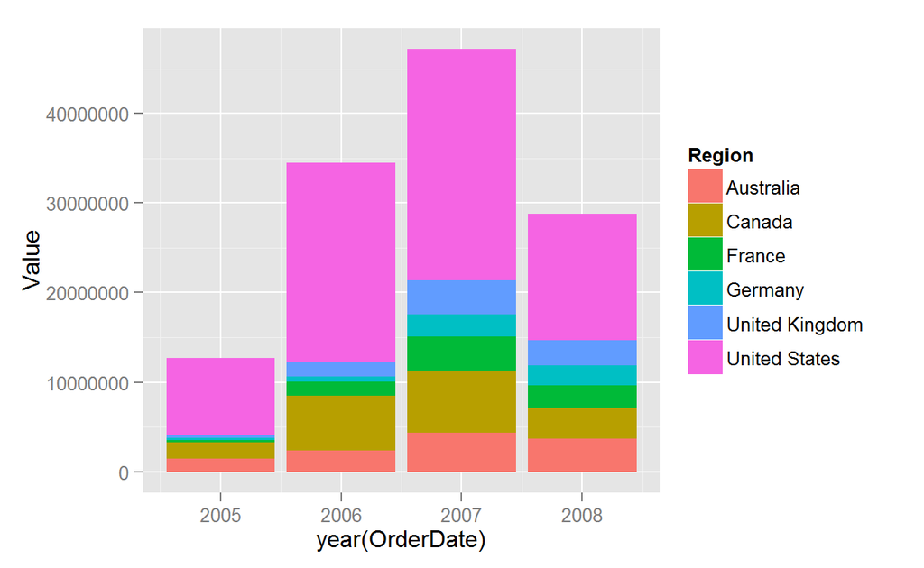

```r
library(ggplot2) # Activate ggplot2

# Quick plot (qplot)
qplot(year(OrderDate), Value,fill=Region,
      data=sales[order(Region)],geom="bar",stat="identity")
```

## Chart anatomy

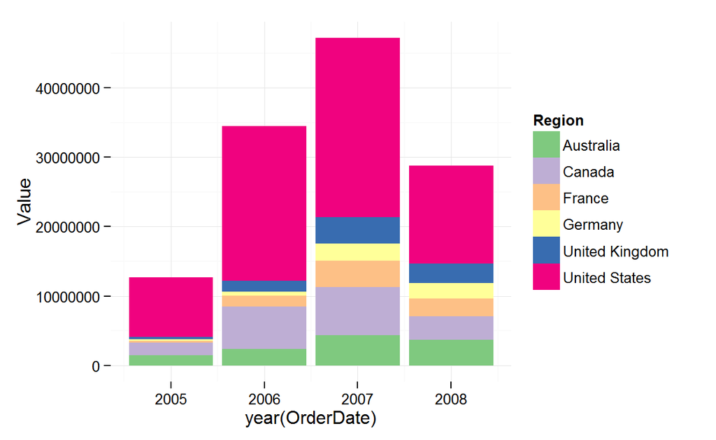

```r
# Chart backbone
ggplot(data=sales[order(Region)],aes(x=year(OrderDate),y=Value,fill=Region))+
  geom_bar(stat="identity")+#bar chart type, identity uses contents not count
  scale_fill_brewer(type="qual")+ #themeing
  theme_minimal()
```

## Making a trellis

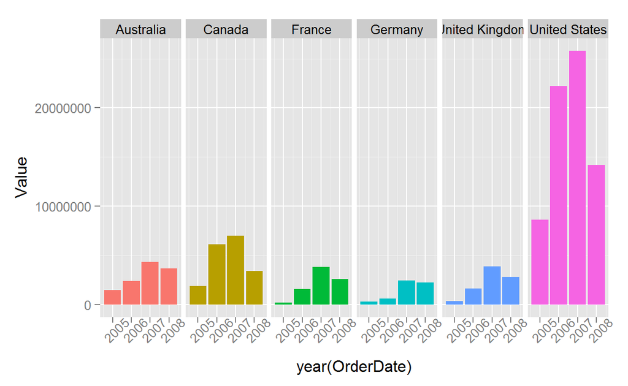

```r
ggplot(data=sales,aes(x=year(OrderDate),y=Value,fill=Region))+
  geom_bar(stat="identity")+
  facet_grid(.~Region)+  # Trellis command
  theme(legend.position="none",axis.text.x=element_text(angle=45))
```

## Formatting

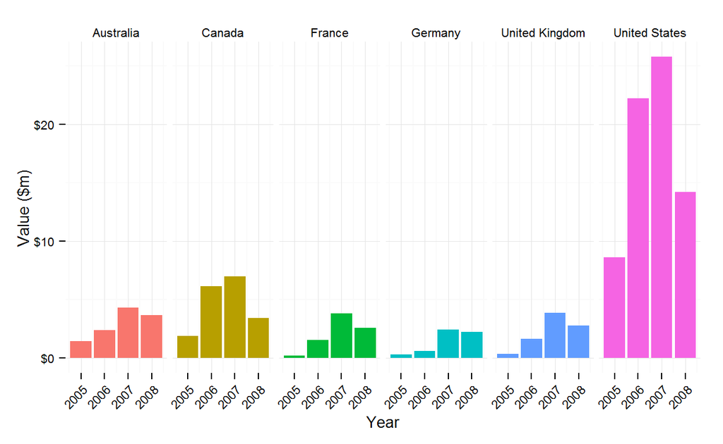

```r
ggplot(data=sales,aes(x=year(OrderDate),y=Value/1000000,fill=Region))+
  geom_bar(stat="identity")+   facet_grid(.~Region)+
  theme_minimal(base_size = 10) +
  theme(legend.position="none",axis.text.x=element_text(angle=45,hjust=1))+
  scale_y_continuous(label=dollar)+
  labs(x="Year",y="Value ($m)")
```

## Interactive documents / reports

- Use knitr with LaTeX or markdown to produce static documents
- Use shiny to make properly interactive reports

### Shiny overview

```
A web application framework for R
Turn your analyses into interactive web applications
No HTML, CSS, or JavaScript knowledge required
```

Uses magic and pixie dust to transform your R code into a webpage that provides end-users with the ability to analyse data interactively

## Shiny paradigm

It's call and response!

- You have client-side controllers that tell server-side code to recalculate content
- There are R functions for input controls, preparing content, and functions that output content.

## Shiny Server

You need a Linux server for this and your applications can be made internally or externally available.

Shiny is by default open, use either a [password system](http://withr.me/blog/2014/01/03/authentication-of-shiny-server-application-using-a-simple-method/) or utilise AD integration in the [pro edition](http://www.rstudio.com/products/shiny/shiny-server/)

### Demo time!

```r
library(shiny)
system.file("examples", package="shiny")
runExample("03_reactivity") # a reactive expression
runExample("05_sliders") # sliders
```

## Dynamic documents

CONCEPT: modular documents that contain text and analysis that update

This is pretty much impossible in the Office paradigm.

- You can make refreshable Excel spreadsheets but stuff with words as well is hard to update
- It's really hard to collaborate on a single Word document
- PowerPoint requires a lot of clicking and C&Ping

R integrates with LaTeX, markdown, and pandoc to enable the blending of code and content to enable documents to be produced from scratch each time.

## What are the benefits?

- Change a bit of the code and the whole document updates
- Modular development enables easier development (particularly in a collaborative setting)
- Reduction in errors caused by C&Ping
- Consistent looks and feel of documents and reports
- Documented as you go
- No stress about updating a document
- Variety of export formats

## How's it done?

- You can write LaTeX and markdown (think wikipedia and SO) outside of R
- There are packages like knitr designed to allow you to embed your R analysis in a variety of other languages
- Work in Rstudio to benefit from their full integration of these packages

### Demo time!

## Find out more

### R resources

- http://tryr.codeschool.com
- http://r-bloggers.com
- http://adv-r.had.co.nz/

### Shiny and Knitr

- http://rmarkdown.rstudio.com/
- http://shiny.rstudio.com/

### LaTeX

- http://en.wikibooks.org/wiki/LaTeX
- http://writelatex.com

## Q&A

## Conclusion

R is a great language that has a wide array of uses. This session covered some of the basics of data manipulation to get you "walking" quickly.

### Follow up

This presentation is available at http://rpubs.com/stephlocke/sqlrelay and the source code is on https://github.com/stephlocke/Rintro

- http://twitter.com/stefflocke
- http://uk.linkedin.com/in/stephanielocke